# practice

```python
import matplotlib.pyplot as plt
import numpy as np
from numpy import pi
from toolbox import solve_bands, kpoints_to_xaxis
plt.rcParams.update({'font.size': 14})
```

## Questions 1: single-band in a 3-D BCC lattice

Given the nearest neighbor sites `Rm` of BCC crystal, please modify the Hamiltonian to plot the band structure.

[figure not shown]

```python
H = {}

H[(0,0,0)] = np.array([
    [0],
])
H[(1/2,1/2,1/2)] = np.array([
    [-1],
])
H[(-1/2,-1/2,-1/2)] = np.array([
    [-1]
])
H[(-1/2,1/2,1/2)] = np.array([
    [-1],
])
H[(-1/2,-1/2,1/2)] = np.array([
    [-1]
])
H[(1/2,-1/2,1/2)] = np.array([
    [-1],
])
H[(1/2,1/2,-1/2)] = np.array([
    [-1]
])
H[(1/2,-1/2,-1/2)] = np.array([
    [-1]
])
H[(-1/2,1/2,-1/2)] = np.array([
    [-1]
])

sk = [
    ('P', [pi,pi,pi]),
    ('G', [ 0, 0, 0]),
    ('N', [ 0,pi,pi]),
    ('H', [0,0,2*pi]),
    ('G', [ 0, 0 ,0]),
]
k1Arr = np.linspace([pi,pi,pi], [ 0, 0, 0], num=20) # P-G
k2Arr = np.linspace([ 0, 0 ,0], [ 0,pi,pi], num=20) # G-N
k3Arr = np.linspace([ 0,pi,pi], [0,0,2*pi], num=20) # N-H
k4Arr = np.linspace([0,0,2*pi], [ 0, 0 ,0], num=20) # H-G
kArr = np.r_[k1Arr, k2Arr, k3Arr, k4Arr]
```

```
Shape of bands: (80, 1)
Number of calculated k-points: 80
Number of bands: 1
```

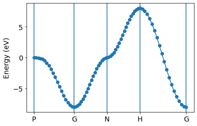

```python
# solve bands
bands = solve_bands(H, kArr)
print(f'Shape of bands: {bands.shape}')
print(f'Number of calculated k-points: {bands.shape[0]}')
print(f'Number of bands: {bands.shape[1]}')
print()

# make x-axis for plotting
xArr = kpoints_to_xaxis(kArr)
hk_labels = [ s[0] for s in sk ]
hk_points = [ s[1] for s in sk ]
hk_xaxis = kpoints_to_xaxis(hk_points)

# plot bands
for band in bands.T:
    plt.plot(xArr, band, '-o')
for i, _ in enumerate(hk_labels):
    plt.axvline(hk_xaxis[i])
plt.ylabel('Energy (eV)')
plt.xticks(hk_xaxis, hk_labels)
plt.show()
```

## Questions 2: single-band in a 3-D FCC lattice

Given the nearest neighbor sites `Rm` of FCC crystal, please modify the Hamiltonian to plot the band structure.

[figure not shown]

```python
H = {}
H[(0,0,0)] = np.array([
    [0],
])
H[(0,1/2,1/2)] = np.array([
    [-1],
])
H[(1/2,0,1/2)] = np.array([
    [-1],
])
H[(1/2,1/2,0)] = np.array([
    [-1],
])
H[(0,-1/2,1/2)] = np.array([
    [-1],
])
H[(0,1/2,-1/2)] = np.array([
    [-1],
])
H[(1/2,0,-1/2)] = np.array([
    [-1],
])
H[(-1/2,0,1/2)] = np.array([
    [-1],
])
H[(1/2,-1/2,0)] = np.array([
    [-1],
])
H[(-1/2,1/2,0)] = np.array([
    [-1],
])
H[(0,-1/2,-1/2)] = np.array([
    [-1],
])
H[(-1/2,0,-1/2)] = np.array([
    [-1],
])
H[(-1/2,-1/2,0)] = np.array([
    [-1],
])

sk = [
    ('L', [pi,pi,pi]),
    ('G', [ 0, 0, 0]),
    ('X', [0,2*pi,0]),
    ('U', [pi/2,2*pi,pi/2]),
    ('W', [pi,2*pi ,0]),
    ('K', [3*pi/2,3*pi/2 ,0]),
    ('G', [ 0, 0 ,0]),
]
k1Arr = np.linspace([pi,pi,pi], [ 0, 0, 0], num=20) # L-G
k2Arr = np.linspace([ 0, 0 ,0], [0,2*pi,0], num=20) # G-X
k3Arr = np.linspace([0,2*pi,0], [pi/2,2*pi,pi/2], num=20) # X-U
k4Arr = np.linspace([pi/2,2*pi,pi/2], [pi,2*pi ,0], num=20) # U-W
k5Arr = np.linspace([pi,2*pi ,0], [3*pi/2,3*pi/2 ,0], num=20) # W-K
k6Arr = np.linspace([3*pi/2,3*pi/2 ,0], [ 0, 0 ,0], num=20) # K-G
kArr = np.r_[k1Arr, k2Arr, k3Arr, k4Arr, k5Arr, k6Arr]
```

```
Shape of bands: (120, 1)
Number of calculated k-points: 120
Number of bands: 1
```

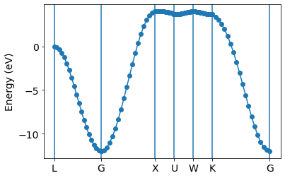

```python
# solve bands
bands = solve_bands(H, kArr)
print(f'Shape of bands: {bands.shape}')
print(f'Number of calculated k-points: {bands.shape[0]}')
print(f'Number of bands: {bands.shape[1]}')
print()

# make x-axis for plotting
xArr = kpoints_to_xaxis(kArr)
hk_labels = [ s[0] for s in sk ]
hk_points = [ s[1] for s in sk ]
hk_xaxis = kpoints_to_xaxis(hk_points)

# plot bands
for band in bands.T:
    plt.plot(xArr, band, '-o')
for i, _ in enumerate(hk_labels):
    plt.axvline(hk_xaxis[i])
plt.ylabel('Energy (eV)')
plt.xticks(hk_xaxis, hk_labels)
plt.show()
```

## Questions 3

In the examples of single-band in a 1-D lattice, the number of basis, `N`, in the unit cell is 1, and you can see only one band in band structure. We can also plot DOS from the band structure. Please recall the definition of DOS and answer the following questions.

1. Now modify the codes to let `N` to be 2, 5 and 10. You will need to modify the Hamiltonian to plot the correct band structure. See the example of grahpene to figure out the rule of building Hamiltonian.
2. What is the relation between band strucutre and DOS in your results?
3. How many bands in your bands structure? Please explain your answer.
4. Does the maximum and minimum energy in your **band structure** change? Does the maximum and minimum energy in your **DOS** change? Please explain your answer.
5. In soild physics, you learn that we can known the physical properties of whole crystal from first Brillouin zones of reciprocal lattice. Here DOS is one of the properties to study. Should the size of the unit cell which you choose change the DOS? If yes, please answer why. If no, how to modify the outputed DOS?

```python
H = {}
t = -1
N = 2

H[(0,0,0)] = np.array([
    [0,-t],
    [-t,0],
])
H[(1,0,0)] = np.array([
    [0, 0],
    [-t,0],
])
H[(-1,0,0)] = np.array([
    [0,-t],
    [ 0,0],
])


k1Arr = np.linspace([-pi, 0 ,0], [pi,0, 0], num=101) # G-X
#k1Arr = np.linspace([-pi*N, 0 ,0], [pi*N,0, 0], num=101) # G-X
kArr = np.r_[k1Arr]
```

```
Shape of bands: (101, 2)
Number of calculated k-points: 101
Number of bands: 2
```

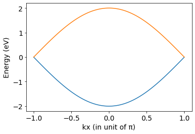

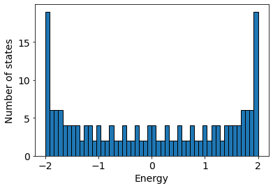

```python
# solve bands
bands = solve_bands(H, kArr)
print(f'Shape of bands: {bands.shape}')
print(f'Number of calculated k-points: {bands.shape[0]}')
print(f'Number of bands: {bands.shape[1]}')
print()

# make x-axis for plotting
xArr = kArr[:,0]/pi

# plot bands
for band in bands.T:
    plt.plot(xArr, band, '-')
plt.xlabel('kx (in unit of π)')
plt.ylabel('Energy (eV)')
plt.show()

# plot DOS
plt.hist(bands.flatten(), bins=50, edgecolor='black')
plt.xlabel('Energy')
plt.ylabel('Number of states')
plt.show()
```

```python
H = {}
t = -1
N = 5

H[(0,0,0)] = np.array([
    [ 0,-t,0,0,0],
    [-t,0,-t,0,0],
    [0,-t,0,-t,0],
    [0,0,-t,0,-t],
    [0, 0,0,-t,0],
])
H[(1,0,0)] = np.array([
    [ 0, 0,0,0,0],
    [ 0,0, 0,0,0],
    [0, 0,0, 0,0],
    [0,0, 0,0, 0],
    [-t, 0,0,0,0],
])
H[(-1,0,0)] = np.array([
    [ 0,0,0,0,-t],
    [ 0,0, 0,0,0],
    [0, 0,0, 0,0],
    [0,0, 0,0, 0],
    [0, 0,0, 0,0],
])


k1Arr = np.linspace([-pi, 0 ,0], [pi,0, 0], num=101) # G-X
#k1Arr = np.linspace([-pi*N, 0 ,0], [pi*N,0, 0], num=101) # G-X
kArr = np.r_[k1Arr]
```

```
Shape of bands: (101, 5)
Number of calculated k-points: 101
Number of bands: 5
```

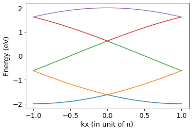

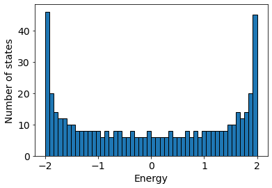

```python
# solve bands
bands = solve_bands(H, kArr)
print(f'Shape of bands: {bands.shape}')
print(f'Number of calculated k-points: {bands.shape[0]}')
print(f'Number of bands: {bands.shape[1]}')
print()

# make x-axis for plotting
xArr = kArr[:,0]/pi

# plot bands
for band in bands.T:
    plt.plot(xArr, band, '-')
plt.xlabel('kx (in unit of π)')
plt.ylabel('Energy (eV)')
plt.show()

# plot DOS
plt.hist(bands.flatten(), bins=50, edgecolor='black')
plt.xlabel('Energy')
plt.ylabel('Number of states')
plt.show()
```

```python
H = {}
t = -1
N = 10

H[(0,0,0)] = np.array([
    [ 0,-t,0,0,0,0,0,0,0,0],
    [-t,0,-t,0,0,0,0,0,0,0],
    [0,-t,0,-t,0,0,0,0,0,0],
    [0,0,-t,0,-t,0,0,0,0,0],
    [0,0,0,-t,0,-t,0,0,0,0],
    [0,0,0,0,-t,0,-t,0,0,0],
    [0,0,0,0,0,-t,0,-t,0,0],
    [0,0,0,0,0,0,-t,0,-t,0],
    [0,0,0,0,0,0,0,-t,0,-t],
    [0,0,0, 0,0,0,0,0,-t,0],
])
H[(1,0,0)] = np.array([
    [ 0,0,0,0,0,0,0,0,0, 0],
    [ 0,0, 0,0,0,0,0,0,0,0],
    [0, 0,0, 0,0,0,0,0,0,0],
    [0,0, 0,0, 0,0,0,0,0,0],
    [0,0,0, 0,0, 0,0,0,0,0],
    [0,0,0,0, 0,0, 0,0,0,0],
    [0,0,0,0,0, 0,0, 0,0,0],
    [0,0,0,0,0,0, 0,0, 0,0],
    [0,0,0,0,0,0,0, 0,0, 0],
    [-t,0,0, 0,0,0,0,0,0,0],
])
H[(-1,0,0)] = np.array([
    [ 0,0,0,0,0,0,0,0,0,-t],
    [ 0,0, 0,0,0,0,0,0,0,0],
    [0, 0,0, 0,0,0,0,0,0,0],
    [0,0, 0,0, 0,0,0,0,0,0],
    [0,0,0, 0,0, 0,0,0,0,0],
    [0,0,0,0, 0,0, 0,0,0,0],
    [0,0,0,0,0, 0,0, 0,0,0],
    [0,0,0,0,0,0, 0,0, 0,0],
    [0,0,0,0,0,0,0, 0,0, 0],
    [ 0,0,0, 0,0,0,0,0,0,0],
])


k1Arr = np.linspace([-pi, 0 ,0], [pi,0, 0], num=101) # G-X
#k1Arr = np.linspace([-pi*N, 0 ,0], [pi*N,0, 0], num=101) # G-X
kArr = np.r_[k1Arr]
```

```
Shape of bands: (101, 10)
Number of calculated k-points: 101
Number of bands: 10
```

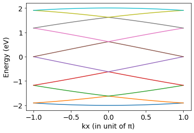

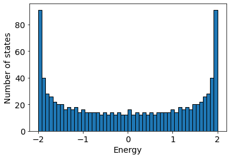

```python
# solve bands
bands = solve_bands(H, kArr)
print(f'Shape of bands: {bands.shape}')
print(f'Number of calculated k-points: {bands.shape[0]}')
print(f'Number of bands: {bands.shape[1]}')
print()

# make x-axis for plotting
xArr = kArr[:,0]/pi

# plot bands
for band in bands.T:
    plt.plot(xArr, band, '-')
plt.xlabel('kx (in unit of π)')
plt.ylabel('Energy (eV)')
plt.show()

# plot DOS
plt.hist(bands.flatten(), bins=50, edgecolor='black')
plt.xlabel('Energy')
plt.ylabel('Number of states')
plt.show()
```

2.What is the relation between band structure and DOS in your results?

The DOS is the density of the lines of the band structure for a specific energy. Integrating DOS to Fermi level will be equal to total number of occupied. The number of orbitals in a band within the first Brillouin zone is equal to the number of unit cells N in the crystal. This is much the same as the statement made in connection with the number of lattice vibrational modes, and is proved in a like manner, by appealing to the boundary conditions. Consider first the one-dimensional case. The allowed values of k form a uniform mesh whose unit spacing is 2π/L. The number of states inside the first zone, whose length is 2π/a, is therefore equal to (2π/a)/(2π/L) = L/a = N, where N is the number of unit cells, in agreement with the assertion made earlier.

3.How many bands in your bands structure? Please explain your answer.

for N= x, there are also x bands in my bands structure. ex: for N= 2, there are 2 bands. Because there are the number of basis = 2. Because outside the Brillouin zone, there is only a periodic change, so as long as it is counted in the first Brillouin zone, how many lines will appear.

4.Does the maximum and minimum energy in your band structure change? Does the maximum and minimum energy in your DOS change? Please explain your answer.

no, all of them from -2 to +2 eV. Because of the repetitive nature of the Brillouin zone, beyond the line of the first Brillouin zone, they can be moved to the first Brillouin zone. In the end, the highest point and the lowest point are the same.

5.In soild physics, you learn that we can known the physical properties of whole crystal from first Brillouin zones of reciprocal lattice. Here DOS is one of the properties to study. Should the size of the unit cell which you choose change the DOS? If yes, please answer why. If no, how to modify the outputed DOS?

change. When the size of the unit cell changes, the size of its Brillouin zone will also be changed. When calculating DOS, it will be based on the data of the Brillouin zone.